# Tutorial Part 2 Quick Start: Basic Operations with nycflights13

ZJ

2020-07-23

## Quick Start - replicating dplyr’s tutorial on nycflight13

In this section, I will demonstrate how to use `{dplyr}` verbs with `{disk.frame}`. This replicate the [sparklyr data manipulation tutorial](https://spark.rstudio.com/dplyr/).

## Set-up `disk.frame`

`disk.frame` works best if it can process multiple data chunks in parallel. The best way to set-up `disk.frame` so that each CPU core runs a background worker is by using

```r
setup_disk.frame()
```

The `setup_disk.frame()` sets up background workers equal to the number of CPU cores; please note that, by default, hyper-threaded cores are counted as one not two.

Alternatively, one may specify the number of workers using `setup_disk.frame(workers = n)`.

## Basic Data Operations with `disk.frame`

The `{disk.frame}` package provides convenient functions to convert `data.frame`s and CSVs to `disk.frame`s.

### Creating a `disk.frame` from `data.frame`

```r
library(nycflights13)
library(dplyr)
library(disk.frame)
library(data.table)

# convert the flights data to a disk.frame and store the disk.frame in the folder
# "tmp_flights" and overwrite any content if needed

output_path = file.path(tempdir(), "tmp_flights.df")

flights.df <- as.disk.frame(
  flights,
  outdir = output_path,
  overwrite = TRUE)

flights.df
```

You should now see a folder called `tmp_flights` with some files in it, namely `1.fst`, `2.fst`…. where each `fst` files is one chunk of the `disk.frame`.

### How to think about a `{disk.frame}`?

It’s useful to think of a *disk.frame* as just a *data.frame*, i.e. it’s a 2D table. In fact, I tried to make `disk.frame` compatible with `data.frame` manipulation syntax. However, it’s also good to understand how a `{disk.frame}` really works.

### The anatomy of a {disk.frame} “file”

A {disk.frame} “file” is a directory of files. Let’s look at the content of the “file”

```r
dir(output_path)
```

```
#> [1] "1.fst" "2.fst" "3.fst" "4.fst" "5.fst" "6.fst"
```

Do you all know about [`fst`](https://www.fstpackage.org/)? You should! See [slides from useR! 2019](https://www.beautiful.ai/-LgwO_sf5qrBouC0H0sG/9).

```r
first_chunk = fst::read_fst(file.path(output_path, "1.fst"))

head(first_chunk)
```

```
#>   year month day dep_time sched_dep_time dep_delay arr_time sched_arr_time
#> 1 2013     1   1      517            515         2      830            819
#> 2 2013     1   1      533            529         4      850            830
#> 3 2013     1   1      542            540         2      923            850
#> 4 2013     1   1      544            545        -1     1004           1022
#> 5 2013     1   1      554            600        -6      812            837
#> 6 2013     1   1      554            558        -4      740            728
#>   arr_delay carrier flight tailnum origin dest air_time distance hour minute
#> 1        11      UA   1545  N14228    EWR  IAH      227     1400    5     15
#> 2        20      UA   1714  N24211    LGA  IAH      227     1416    5     29
#> 3        33      AA   1141  N619AA    JFK  MIA      160     1089    5     40
#> 4       -18      B6    725  N804JB    JFK  BQN      183     1576    5     45
#> 5       -25      DL    461  N668DN    LGA  ATL      116      762    6      0
#> 6        12      UA   1696  N39463    EWR  ORD      150      719    5     58
#>             time_hour
#> 1 2013-01-01 05:00:00
#> 2 2013-01-01 05:00:00
#> 3 2013-01-01 05:00:00
#> 4 2013-01-01 05:00:00
#> 5 2013-01-01 06:00:00
#> 6 2013-01-01 05:00:00
```

Each file is called a **chunk**. `{disk.frame}` tries to work with MULTIPLE chunks in parallel. This is one of two “secrets” to `{disk.frame}`’s speed.

A lot of operations can be performed in parallel, a few chunks at a time

- `filter`
- `mutate`
- certain `group_by` and `summarize` pairs

So `{disk.frame}` does the job of translating `dplyr` verbs (or `cmap` operations; you will learn these later on in the tutorial) into parallel operations for you

```r
result <- flights.df %>%
  filter(year = 2003) %>%
  collect
```

the above will be translated into this many parallel processes

```r
files = paste0(1:6, ".fst")

list.of.data.frame <- future.apply::future_lapply(files, function(file) {
  fst::read_fst(file.path(output_path, file))
})

# row-bind them together
result <- do.call(rbind, list.of.data.frame)

# or if you prefer data.table
result <- rbindlist(list.of.data.frame)

# or if you prefer dplyr
result <- bind_rows(list.of.data.frame)

# or if you prefer purrr
result <- map_dfr(list.of.data.frame, identity)
```

##### How many workers is `{disk.frame}` using?

```r
future::nbrOfWorkers()
```

You can customize that with

```r
setup_disk.frame(workers = nworkers)
```

`{disk.frame}` uses `{future}` as the parallelization backend, so all options that affect `{future}` will also impact `{disk.frame}`. For examples, this options allows unlimited data to be passed between R sessions.

```r
# this will allow unlimited amount of data to be passed from worker to worker
options(future.globals.maxSize = Inf)
```

### Creating a `disk.frame` from CSV

One of the most common ways to ingest data is via CSV. {disk.frame} provides a way to read CSV using `csv_to_disk.frame`. In a later part of the tutorial I will talk about ingesting data in more depth.

```r
library(nycflights13)
# write a csv
csv_path = file.path(tempdir(), "tmp_flights.csv")
data.table::fwrite(flights, csv_path)

# load the csv into a disk.frame
df_path = file.path(tempdir(), "tmp_flights.df")
flights.df <- csv_to_disk.frame(
  csv_path,
  outdir = df_path,
  overwrite = T)

flights.df
```

If the CSV is too large to read in, then we can also use the `in_chunk_size` option to control how many rows to read in at once. For example to read in the data 100,000 rows at a time.

```r
library(nycflights13)
library(disk.frame)

# write a csv
csv_path = file.path(tempdir(), "tmp_flights.csv")

data.table::fwrite(flights, csv_path)

df_path = file.path(tempdir(), "tmp_flights.df")

flights.df <- csv_to_disk.frame(
  csv_path,
  outdir = df_path,
  in_chunk_size = 100000) # the in_chunk_size can typically be omitted, {disk.frame} will "guess-timate" it

flights.df
```

`disk.frame` also has a function `zip_to_disk.frame` that can convert every CSV in a zip file to `disk.frame`s.

### Simple `dplyr` verbs and lazy evaluation

One can chain `dplyr` verbs together like with a `data.frame`

```r
c4 <- flights.df %>%
  srckeep(c("month", "day", "carrier", "dep_delay", "air_time", "distance")) %>%
  filter(month == 5, day == 17, carrier %in% c('UA', 'WN', 'AA', 'DL')) %>%
  select(carrier, dep_delay, air_time, distance) %>%
  mutate(air_time_hours = air_time / 60) %>%
  collect %>% # collect the data into memory
  arrange(carrier)# arrange should occur after `collect`

c4  %>% head
```

```
#>   carrier dep_delay air_time distance air_time_hours
#> 1      AA        -7      142     1089       2.366667
#> 2      AA        -9      186     1389       3.100000
#> 3      AA        -6      143     1096       2.383333
#> 4      AA        -4      114      733       1.900000
#> 5      AA        -2      146     1085       2.433333
#> 6      AA        -7      119      733       1.983333
```

- `disk.frame` operations are **lazy** by default, meaning it doesn’t perform the operations right away.
- you need to call `collect` for actions to be carried out
- Exceptions to this rule are the `*_join` operations which are evaluated *eagerly* under certain conditions see **Joins for disk.frame in-depth** for details.

For example, `flights1.df1` is lazy. The function `collect` can be used to bring the results from disk into R, e.g.

```r
system.time(
  flights1.df <- flights.df %>%
    srckeep(c("month", "day", "carrier", "dep_delay", "air_time", "distance")) %>%
    filter(month == 5, day == 17, carrier %in% c('UA', 'WN', 'AA', 'DL')) %>%
    select(carrier, dep_delay, air_time, distance) %>%
    mutate(air_time_hours = air_time / 60)
)
```

```
#>    user  system elapsed
#>    0.03    0.00    0.03
```

```r
system.time(flights1_collected <- collect(flights1.df))
```

```
#>    user  system elapsed
#>    0.10    0.00    1.23
```

```r
class(flights1_collected)
```

```
#> [1] "data.frame"
```

Of course, for larger-than-RAM datasets, one wouldn’t call `collect` on the whole `disk.frame` (because why would you need `disk.frame` otherwise). More likely, one would call `collect` on a `filter`ed dataset or one summarized with `group_by`.

### List of supported `dplyr` verbs

```r
select
rename
filter
chunk_arrange # within each chunk
chunk_group_by # within each chunk
chunk_summarize # within each chunk
group_by # limited functions
summarize # limited functions
mutate
transmute
left_join
inner_join
full_join # careful. Performance!
semi_join
anit_join
```

## Group-by

`{disk.frame}` implements the `group_by` operation some caveats. In the `{disk.frame}` framework, only a set functions are supported in `summarize`. However, the user can create more custom `group-by` functions can be defined.

```r
system.time(
  flights.df %>%
    group_by(carrier) %>% # notice that hard_group_by needs to be set
    summarize(count = n(), mean_dep_delay = mean(dep_delay, na.rm=T)) %>%  # mean follows normal R rules
    collect %>%
    arrange(carrier)
)
```

```
#>    user  system elapsed
#>    0.58    0.06    1.16
```

## Restrict input columns for faster processing

One can restrict which input columns to load into memory for each chunk; this can significantly increase the speed of data processing. To restrict the input columns, use the `srckeep` function which only accepts column names as a string vector.

```r
system.time(
  flights.df %>%
    srckeep(c("carrier","dep_delay")) %>%
    group_by(carrier) %>%
    summarize(count = n(), mean_dep_delay = mean(dep_delay, na.rm=T)) %>%  # mean follows normal R rules
    collect
)
```

```
#>    user  system elapsed
#>    0.54    0.07    1.07
```

Input column restriction is one of the most critical efficiencies provided by `disk.frame`. Because the underlying format allows random access to columns (i.e. retrieve only the columns used for processing), hence one can drastically reduce the amount of data loaded into RAM for processing by keeping only those columns that are directly used to produce the results.

## Joins

`disk.frame` supports many dplyr joins including:

```r
left_join
inner_join
semi_join
inner_join
full_join # requires hard_group_by on both left and right
```

In all cases, the left dataset (`x`) must be a `disk.frame`, and the right dataset (`y`) can be either a `disk.frame` or a `data.frame`. If the right dataset is a `disk.frame` and the `shardkey`s are different between the two `disk.frame`s then two expensive `hard` `group_by` operations are performed *eagerly*, one on the left `disk.frame` and one on the right `disk.frame` to perform the joins correctly.

However, if the right dataset is a `data.frame` then `hard_group_by`s are only performed in the case of `full_join`.

Note `disk.frame` does not support `right_join` the user should use `left_join` instead.

The below joins are performed *lazily* because `airlines.dt` is a `data.table` not a `disk.frame`:

```r
# make airlines a data.table
airlines.dt <- data.table(airlines)

# perform a left join
flights.df %>%
  left_join(airlines.dt, by ="carrier") %>%
  collect %>%
  arrange(year, month, day, dep_time, sched_dep_time)
```

```
#>         year month day dep_time sched_dep_time dep_delay arr_time
#>      1: 2013     1   1      517            515         2      830
#>      2: 2013     1   1      533            529         4      850
#>      3: 2013     1   1      542            540         2      923
#>      4: 2013     1   1      544            545        -1     1004
#>      5: 2013     1   1      554            558        -4      740
#>     ---
#> 336772: 2013    12  31       NA           1520        NA       NA
#> 336773: 2013    12  31       NA           1615        NA       NA
#> 336774: 2013    12  31       NA           1932        NA       NA
#> 336775: 2013    12  31       NA           2000        NA       NA
#> 336776: 2013    12  31       NA           2025        NA       NA
#>         sched_arr_time arr_delay carrier flight tailnum origin dest air_time
#>      1:            819        11      UA   1545  N14228    EWR  IAH      227
#>      2:            830        20      UA   1714  N24211    LGA  IAH      227
```

[output cut: 21 more lines]

```r
# convert the data to disk.frame
airlines.df = as.disk.frame(airlines.dt)

system.time(
  flights.df %>%
    left_join(airlines.df, by = c("carrier")) %>%
    collect %>%
    arrange(year, month, day, dep_time, sched_dep_time)
)
```

### How does `merge_by_chunk_id` work?

```r
disk.frame1 %>%
  left_join(disk.frame2, merge_by_chunk_id = FALSE)
```

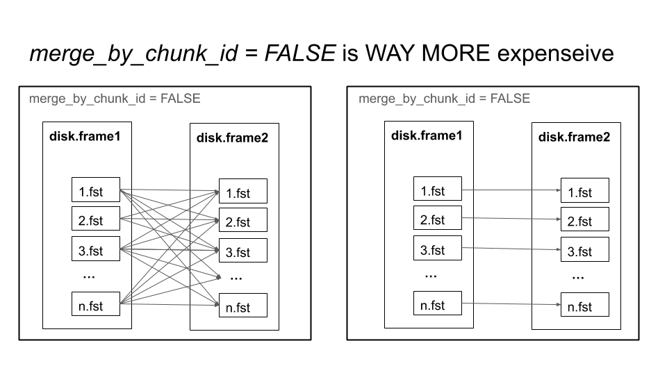

merge_by_chunk_id

## Sharding and distribution of chunks

How do I make sure that `merge_by_chunk_id` works? Say, if I am merging by `customer_id`. How do I know the same `customer_id` will end up in the same chunk for two different `disk.farme`s?

The answer is sharding. See

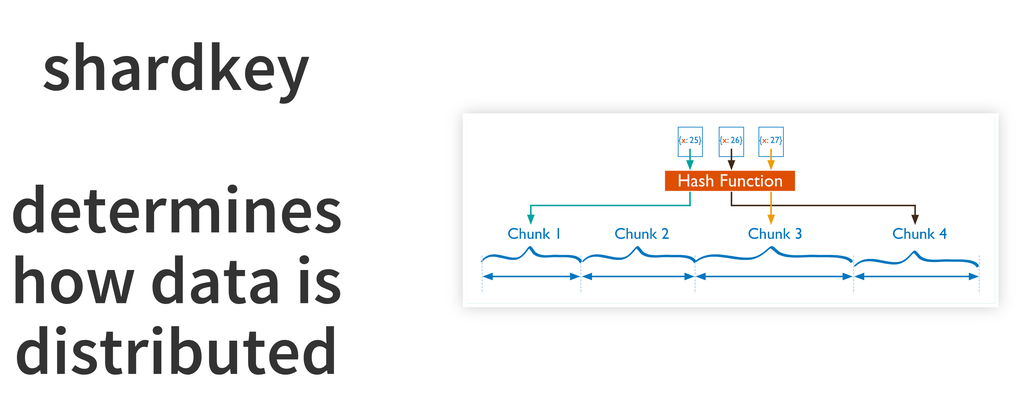

sharding

If you shard by particular columns, then all columns with the same values will go to the same chunks.

Two ways to do sharding

```r
# 1. specify it at read time
csv_to_disk.frame(path_to_csv,..., shardby = c("col1", "col2"))

# 2. rechunk an existing disk.frame
rechunk(a.disk.frame, shardby = = c("col1", "col2"))
```

In our `flights` example, we do

```r
flights.sharded.df = shard(flights.df, shardby = c("carrier"))
airlines.sharded.df = shard(airlines.df, shardby = c("carrier"))

system.time(
  left_join_result2 <- flights.df %>%
    left_join(airlines.df, by = c("carrier"), merge_by_chunk_id = TRUE) %>%
    collect %>%
    arrange(year, month, day, dep_time, sched_dep_time)
)
```

```
#>    user  system elapsed
#>    0.50    0.44    2.01
```

```r
left_join_result2
```

```
#>         year month day dep_time sched_dep_time dep_delay arr_time
#>      1: 2013     1   1      517            515         2      830
#>      2: 2013     1   1      533            529         4      850
#>      3: 2013     1   1      542            540         2      923
#>      4: 2013     1   1      544            545        -1     1004
#>      5: 2013     1   1      554            558        -4      740
#>     ---
#> 336772: 2013    12  31       NA           1520        NA       NA
#> 336773: 2013    12  31       NA           1615        NA       NA
#> 336774: 2013    12  31       NA           1932        NA       NA
#> 336775: 2013    12  31       NA           2000        NA       NA
#> 336776: 2013    12  31       NA           2025        NA       NA
#>         sched_arr_time arr_delay carrier flight tailnum origin dest air_time
#>      1:            819        11      UA   1545  N14228    EWR  IAH      227
#>      2:            830        20      UA   1714  N24211    LGA  IAH      227
```

[output cut: 21 more lines]

Like other distributed data manipulation frameworks `disk.frame` utilizes the *sharding* concept to distribute the data into chunks. For example “to shard by `cust_id`” means that all rows with the same `cust_id` will be stored in the same chunk. This enables `chunk_group_by` by `cust_id` to produce the same results as non-chunked data.

The `by` variables that were used to shard the dataset are called the `shardkey`s. The *sharding* is performed by computing a deterministic hash on the shard keys (the `by` variables) for each row. The hash function produces an integer between `1` and `n`, where `n` is the number of chunks.

If you plan to use `shard` or required certain rows to be in the same chunk (e.g. some group-by operations), it is adviced that plan ahead!

## Window functions and arbitrary functions

### It’s hard to do group-by in chunks

The data is stored in chunks. How to handle the below?

```r
diskf %>%
  group_by(grp) %>%
  summarize(meanx = mean(x))
```

I would need to “coordinate” the computation of all the chunks. I will discussed in more depth in the group-by section of the tutorial.

For now, understand that because of the chunk structure, not all `summarize` functions are supported at this stage. This is the list of `summarize` function currently supported by `{disk.frame}`

| Function | Exact/Estimate | Notes |
| --- | --- | --- |
| `min` | Exact |  |
| `max` | Exact |  |
| `mean` | Exact |  |
| `sum` | Exact |  |
| `length` | Exact |  |
| `n` | Exact |  |
| `n_distinct` | Exact |  |
| `sd` | Exact |  |
| `var` | Exact | `var(x)` only `cor, cov` support *planned* |
| `any` | Exact |  |
| `all` | Exact |  |
| `median` | Estimate |  |
| `quantile` | Estimate | One quantile only |
| `IQR` | Estimate |  |

### `hard_group_by` and `chunk_group_by`

For tasks not achievable with group-by. We provide two other functions

`hard_group_by` - the same as group-by but re-organizes the chunks on disk by sharding them by the group-by columns - VERY EXPENSIVE `chunk_group_by` - performances the group-by within chunks. Friends with `chunk_summarize`

We won’t discuss these in depth in this tutorial.

#### Some examples

`{disk.frame}` supports all `data.frame` operations, unlike Spark which can only perform those operations that Spark has implemented. Hence windowing functions like `min_rank` and `rank` are supported out of the box.

For the following example, we will use the `hard_group_by` which performs a group-by and also re-organizes the chunks so that all records with the same `year`, `month`, and `day` end up in the same chunk. This is typically not advised, as `hard_group_by` can be slow for large datasets.

```r
# Find the most and least delayed flight each day
bestworst <- flights.df %>%
   srckeep(c("year","month","day", "dep_delay")) %>%
   hard_group_by(c("year", "month", "day")) %>%
   filter(dep_delay == min(dep_delay, na.rm = T) || dep_delay == max(dep_delay, na.rm = T)) %>%
   collect

bestworst %>% head
```

another example

```r
ranked <- flights.df %>%
  srckeep(c("year","month","day", "dep_delay")) %>%
  hard_group_by(c("year", "month", "day")) %>%
  filter(min_rank(desc(dep_delay)) <= 2 & dep_delay > 0) %>%
  collect

ranked %>% head
```

one more example

```r
# Rank each flight within a daily
ranked <- flights.df %>%
  srckeep(c("year","month","day", "dep_delay")) %>%
  group_by(year, month, day) %>%
  mutate(rank = rank(desc(dep_delay))) %>%
  collect

ranked %>% head
```

```
#>   year month day dep_delay    rank
#> 1 2013     1   1         2 20787.5
#> 2 2013     1   1         4 18859.5
#> 3 2013     1   1         2 20787.5
#> 4 2013     1   1        -1 27367.5
#> 5 2013     1   1        -6 46212.0
#> 6 2013     1   1        -4 38630.0
```

```r
# Rank each flight within a daily
ranked <- flights %>%
  select(c("year","month","day", "dep_delay")) %>%
  group_by(year, month, day) %>%
  mutate(rank = rank(desc(dep_delay))) %>%
  collect

ranked %>% head
# Rank each flight within a daily
ranked <- flights.df %>%
  srckeep(c("year","month","day", "dep_delay")) %>%
  chunk_group_by(year, month, day) %>%
  mutate(rank = rank(desc(dep_delay))) %>%
  collect

ranked %>% head
```

## Arbitrary by-chunk processing

One can apply arbitrary transformations to each chunk of the `disk.frame` by using the `delayed` function which evaluates lazily or the `cmap(lazy = F)` function which evaluates eagerly. For example to return the number of rows in each chunk

```r
flights.df1 <- delayed(flights.df, ~nrow(.x))
collect_list(flights.df1) %>% head # returns number of rows for each data.frame in a list
```

```
#> [[1]]
#> [1] 56131
#>
#> [[2]]
#> [1] 56131
#>
#> [[3]]
#> [1] 56131
#>
#> [[4]]
#> [1] 56131
#>
#> [[5]]
#> [1] 56131
#>
#> [[6]]
#> [1] 56121
```

and to do the same with `cmap`

```r
cmap(flights.df, ~nrow(.x), lazy = F) %>% head
```

```
#> [[1]]
#> [1] 56131
#>
#> [[2]]
#> [1] 56131
#>
#> [[3]]
#> [1] 56131
#>
#> [[4]]
#> [1] 56131
#>
#> [[5]]
#> [1] 56131
#>
#> [[6]]
#> [1] 56121
```

The `cmap` function can also output the results to another `disk.frame` folder, e.g.

```r
# return the first 10 rows of each chunk
flights.df2 <- map(flights.df, ~.x[1:10,], lazy = F, outdir = file.path(tempdir(), "tmp2"), overwrite = T)
flights.df2 %>% head
```

```
#>    year month day dep_time sched_dep_time dep_delay arr_time sched_arr_time
#> 1: 2013     1   1      517            515         2      830            819
#> 2: 2013     1   1      533            529         4      850            830
#> 3: 2013     1   1      542            540         2      923            850
#> 4: 2013     1   1      544            545        -1     1004           1022
#> 5: 2013     1   1      554            600        -6      812            837
#> 6: 2013     1   1      554            558        -4      740            728
#>    arr_delay carrier flight tailnum origin dest air_time distance hour minute
#> 1:        11      UA   1545  N14228    EWR  IAH      227     1400    5     15
#> 2:        20      UA   1714  N24211    LGA  IAH      227     1416    5     29
#> 3:        33      AA   1141  N619AA    JFK  MIA      160     1089    5     40
#> 4:       -18      B6    725  N804JB    JFK  BQN      183     1576    5     45
#> 5:       -25      DL    461  N668DN    LGA  ATL      116      762    6      0
#> 6:        12      UA   1696  N39463    EWR  ORD      150      719    5     58
#>               time_hour
#> 1: 2013-01-01T10:00:00Z
#> 2: 2013-01-01T10:00:00Z
#> 3: 2013-01-01T10:00:00Z
#> 4: 2013-01-01T10:00:00Z
#> 5: 2013-01-01T11:00:00Z
#> 6: 2013-01-01T10:00:00Z
```

Notice `{disk.frame}` supports the `purrr` syntax for defining a function using `~`.

## Sampling

In the `disk.frame` framework, sampling a proportion of rows within each chunk can be performed using `sample_frac`.

```r
flights.df %>% sample_frac(0.01) %>% collect %>% head
```

```
#>   year month day dep_time sched_dep_time dep_delay arr_time sched_arr_time
#> 1 2013     1   6      825            830        -5     1320           1335
#> 2 2013     1   6      737            740        -3     1039           1040
#> 3 2013    12  24     1657           1700        -3     2004           2020
#> 4 2013     5  11     1644           1632        12     2014           1956
#> 5 2013     1  12     1959           2000        -1     2109           2125
#> 6 2013     1  19     1659           1700        -1     1949           2006
#>   arr_delay carrier flight tailnum origin dest air_time distance hour minute
#> 1       -15      DL    301  N3748Y    JFK  SJU      200     1598    8     30
#> 2        -1      UA    759  N437UA    EWR  TPA      162      997    7     40
#> 3       -16      AA    172  N631AA    EWR  MIA      156     1085   17      0
#> 4        18      B6    675  N641JB    JFK  LAX      322     2475   16     32
#> 5       -16      WN    825  N419WN    LGA  MDW      113      725   20      0
#> 6       -17      B6    509  N571JB    EWR  FLL      149     1065   17      0
#>              time_hour
#> 1 2013-01-06T13:00:00Z
#> 2 2013-01-06T12:00:00Z
#> 3 2013-12-24T22:00:00Z
#> 4 2013-05-11T20:00:00Z
#> 5 2013-01-13T01:00:00Z
#> 6 2013-01-19T22:00:00Z
```

## Writing Data

One can output a `disk.frame` by using the `write_disk.frame` function. E.g.

```r
write_disk.frame(flights.df, outdir="out")
```

this will output a disk.frame to the folder “out”

We will expand on this in the next section.

## What’s covered in this section?

- Many `dplyr` verbs are implemented for data manipulation
- `XYZ_join` are implemented. For performances, the right table to be data.frame, or shard both the left and right `disk.frame`s
- The concept of *sharding*
- Group-by and summarization are possible for many operations
- `sample_frac` for sampling a fraction of each chunk
- `write_disk.frame` for writing out new `disk.frame`s